```python
import pandas as pd
import numpy as np
import matplotlib.pyplot as plt
import seaborn as sns
import datetime
import warnings
warnings.filterwarnings('ignore')
from sklearn.preprocessing import StandardScaler, MinMaxScaler
from scipy.stats import boxcox
from sklearn.cluster import KMeans
from sklearn.decomposition import PCA
```

```python
df = pd.read_csv('flight.csv')
```

# 1. EDA

Lakukan EDA pada dataset untuk mendapatkan pemahaman umum mengenai data dan memandu proses feature engineering  
Langkah-langkah:

- Pastikan setiap kolom dataset memiliki tipe data yang tepat, tidak ada data yang kosong, bebas dari duplikat, dan berada di range value yang tepat
- Keluarkan Statistik kolom baik numerik maupun kategoical, cari bentuk distribusi setiap kolom (numerik), dan jumlah baris untuk setiap unique value (kategorikal)
- Cari tahu apakah ada kolom-kolom yang berkorelasi kuat satu sama lain

```python
df.info()
```

```
<class 'pandas.core.frame.DataFrame'>
RangeIndex: 62988 entries, 0 to 62987
Data columns (total 23 columns):
 #   Column             Non-Null Count  Dtype
---  ------             --------------  -----
 0   MEMBER_NO          62988 non-null  int64
 1   FFP_DATE           62988 non-null  object
 2   FIRST_FLIGHT_DATE  62988 non-null  object
 3   GENDER             62985 non-null  object
 4   FFP_TIER           62988 non-null  int64
 5   WORK_CITY          60719 non-null  object
 6   WORK_PROVINCE      59740 non-null  object
 7   WORK_COUNTRY       62962 non-null  object
 8   AGE                62568 non-null  float64
 9   LOAD_TIME          62988 non-null  object
 10  FLIGHT_COUNT       62988 non-null  int64
 11  BP_SUM             62988 non-null  int64
 12  SUM_YR_1           62437 non-null  float64
 13  SUM_YR_2           62850 non-null  float64
 14  SEG_KM_SUM         62988 non-null  int64
 15  LAST_FLIGHT_DATE   62988 non-null  object
 16  LAST_TO_END        62988 non-null  int64
 17  AVG_INTERVAL       62988 non-null  float64
 18  MAX_INTERVAL       62988 non-null  int64
 19  EXCHANGE_COUNT     62988 non-null  int64
 20  avg_discount       62988 non-null  float64
 21  Points_Sum         62988 non-null  int64
 22  Point_NotFlight    62988 non-null  int64
dtypes: float64(5), int64(10), object(8)
memory usage: 11.1+ MB
```

```python
numeric = df.loc[:, (df.dtypes == np.int64) | (df.dtypes == np.float64)].columns.tolist()
numeric
```

```
['MEMBER_NO',
 'FFP_TIER',
 'AGE',
 'FLIGHT_COUNT',
 'BP_SUM',
 'SUM_YR_1',
 'SUM_YR_2',
 'SEG_KM_SUM',
 'LAST_TO_END',
 'AVG_INTERVAL',
 'MAX_INTERVAL',
 'EXCHANGE_COUNT',
 'avg_discount',
 'Points_Sum',
 'Point_NotFlight']
```

```python
categorical = df.loc[:, (df.dtypes != np.int64) & (df.dtypes != np.float64)].columns.tolist()
categorical
```

```
['FFP_DATE',
 'FIRST_FLIGHT_DATE',
 'GENDER',
 'WORK_CITY',
 'WORK_PROVINCE',
 'WORK_COUNTRY',
 'LOAD_TIME',
 'LAST_FLIGHT_DATE']
```

# Mengecek nilai data yang kosong

```python
data_missing_value = df.isnull().sum().reset_index()
data_missing_value.columns = ['feature','missing_value']
data_missing_value['percentage'] = round((data_missing_value['missing_value']/len(df))*100,3)
data_missing_value = data_missing_value.sort_values('percentage', ascending=False).reset_index(drop=True)
data_missing_value = data_missing_value[data_missing_value['percentage']>0]
data_missing_value
```

|  | feature | missing_value | percentage |
| --- | --- | --- | --- |
| 0 | WORK_PROVINCE | 3248 | 5.157 |
| 1 | WORK_CITY | 2269 | 3.602 |
| 2 | SUM_YR_1 | 551 | 0.875 |
| 3 | AGE | 420 | 0.667 |
| 4 | SUM_YR_2 | 138 | 0.219 |
| 5 | WORK_COUNTRY | 26 | 0.041 |
| 6 | GENDER | 3 | 0.005 |

```python
df_clean = df.copy()
```

```python
drop_column = ['SUM_YR_1','AGE','SUM_YR_2','WORK_COUNTRY','GENDER']
for col in drop_column:
    df_clean.dropna(subset=[col], inplace=True)
```

Untuk kolom `WORK_CITY` dan `WORK_PRROVINCE`, kami akan memasukkan nilai modus untuk mengisi nilai yang kosong

```python
df_clean['WORK_CITY'].fillna(df_clean['WORK_CITY'].mode()[0], inplace=True)
df_clean['WORK_PROVINCE'].fillna(df_clean['WORK_PROVINCE'].mode()[0], inplace=True)
```

```python
data_missing_value = df_clean.isnull().sum().reset_index()
data_missing_value.columns = ['feature','missing_value']
data_missing_value
```

|  | feature | missing_value |
| --- | --- | --- |
| 0 | MEMBER_NO | 0 |
| 1 | FFP_DATE | 0 |
| 2 | FIRST_FLIGHT_DATE | 0 |
| 3 | GENDER | 0 |
| 4 | FFP_TIER | 0 |
| 5 | WORK_CITY | 0 |
| 6 | WORK_PROVINCE | 0 |
| 7 | WORK_COUNTRY | 0 |
| 8 | AGE | 0 |
| 9 | LOAD_TIME | 0 |
| 10 | FLIGHT_COUNT | 0 |
| 11 | BP_SUM | 0 |
| 12 | SUM_YR_1 | 0 |
| 13 | SUM_YR_2 | 0 |
| 14 | SEG_KM_SUM | 0 |
| 15 | LAST_FLIGHT_DATE | 0 |
| 16 | LAST_TO_END | 0 |
| 17 | AVG_INTERVAL | 0 |
| 18 | MAX_INTERVAL | 0 |
| 19 | EXCHANGE_COUNT | 0 |
| 20 | avg_discount | 0 |
| 21 | Points_Sum | 0 |
| 22 | Point_NotFlight | 0 |

# Mengecek data duplicated

```python
# Duplicated data
df.duplicated().sum()
```

```
0
```

```python
# drop duplicated rows
print(f'Jumlah row duplicated sebelum dihapus {df.duplicated().sum()}')
df.drop_duplicates(inplace=True) # note: default-nya keep='First' (tidak perlu ditulis)
print(f'Jumlah row duplicated SETELAH dihapus {df.duplicated().sum()}')
```

```
Jumlah row duplicated sebelum dihapus 0
Jumlah row duplicated SETELAH dihapus 0
```

# Mengecek range data

```python
df[numeric].describe()
```

|  | MEMBER_NO | FFP_TIER | AGE | FLIGHT_COUNT | BP_SUM | SUM_YR_1 | SUM_YR_2 | SEG_KM_SUM | LAST_TO_END | AVG_INTERVAL | MAX_INTERVAL | EXCHANGE_COUNT | avg_discount | Points_Sum | Point_NotFlight |
| --- | --- | --- | --- | --- | --- | --- | --- | --- | --- | --- | --- | --- | --- | --- | --- |
| count | 62988.000000 | 62988.000000 | 62568.000000 | 62988.000000 | 62988.000000 | 62437.000000 | 62850.000000 | 62988.000000 | 62988.000000 | 62988.000000 | 62988.000000 | 62988.000000 | 62988.000000 | 62988.0000 | 62988.000000 |
| mean | 31494.500000 | 4.102162 | 42.476346 | 11.839414 | 10925.081254 | 5355.376064 | 5604.026014 | 17123.878691 | 176.120102 | 67.749788 | 166.033895 | 0.319775 | 0.721558 | 12545.7771 | 2.728155 |
| std | 18183.213715 | 0.373856 | 9.885915 | 14.049471 | 16339.486151 | 8109.450147 | 8703.364247 | 20960.844623 | 183.822223 | 77.517866 | 123.397180 | 1.136004 | 0.185427 | 20507.8167 | 7.364164 |
| min | 1.000000 | 4.000000 | 6.000000 | 2.000000 | 0.000000 | 0.000000 | 0.000000 | 368.000000 | 1.000000 | 0.000000 | 0.000000 | 0.000000 | 0.000000 | 0.0000 | 0.000000 |
| 25% | 15747.750000 | 4.000000 | 35.000000 | 3.000000 | 2518.000000 | 1003.000000 | 780.000000 | 4747.000000 | 29.000000 | 23.370370 | 79.000000 | 0.000000 | 0.611997 | 2775.0000 | 0.000000 |
| 50% | 31494.500000 | 4.000000 | 41.000000 | 7.000000 | 5700.000000 | 2800.000000 | 2773.000000 | 9994.000000 | 108.000000 | 44.666667 | 143.000000 | 0.000000 | 0.711856 | 6328.5000 | 0.000000 |
| 75% | 47241.250000 | 4.000000 | 48.000000 | 15.000000 | 12831.000000 | 6574.000000 | 6845.750000 | 21271.250000 | 268.000000 | 82.000000 | 228.000000 | 0.000000 | 0.809476 | 14302.5000 | 1.000000 |
| max | 62988.000000 | 6.000000 | 110.000000 | 213.000000 | 505308.000000 | 239560.000000 | 234188.000000 | 580717.000000 | 731.000000 | 728.000000 | 728.000000 | 46.000000 | 1.500000 | 985572.0000 | 140.000000 |

- Pada kolom `AGE` tampak sudah membentuk distribusi positif karena nilai mean dan mediannya tidak beda jauh
- Pada kolom `SUM_YR_1`, `SUM_YR_2` membetuk Positif skewed karena nilai Mean > median
- Pada kolom `avg_discount` memiliki nilai minimal 0 sehingga harus dilakukan analisis pada kolom tersebut
- Melihat customer yang memililiki umur 110 tahun, sehingga data tersebut harus dihapus karena tidak normal

```python
df[categorical].describe()
```

|  | FFP_DATE | FIRST_FLIGHT_DATE | GENDER | WORK_CITY | WORK_PROVINCE | WORK_COUNTRY | LOAD_TIME | LAST_FLIGHT_DATE |
| --- | --- | --- | --- | --- | --- | --- | --- | --- |
| count | 62988 | 62988 | 62985 | 60719 | 59740 | 62962 | 62988 | 62988 |
| unique | 3068 | 3406 | 2 | 3234 | 1165 | 118 | 1 | 731 |
| top | 1/13/2011 | 2/16/2013 | Male | guangzhou | guangdong | CN | 3/31/2014 | 3/31/2014 |
| freq | 184 | 96 | 48134 | 9386 | 17509 | 57748 | 62988 | 959 |

- Pada data tesebut memiliki 8 kategorical kolom
- Mayoritas pelanggan adalah laki-laki yang memiliki frekuensi 48134

# Statistik kolom numerik

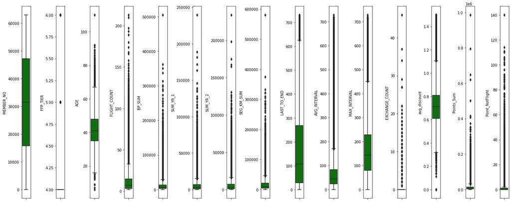

```python
plt.figure(figsize=(20,8))
for i in range(0, len(numeric)):
    plt.subplot(1, len(numeric), i+1)
    sns.boxplot(y=df[numeric[i]], color='green', orient='v')
    plt.tight_layout()
```

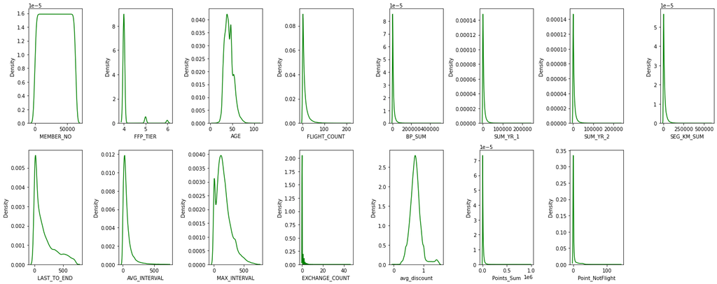

```python
plt.figure(figsize=(20,8))
for i in range(0, len(numeric)):
    plt.subplot(2, 8, i+1)
    sns.kdeplot(x=df[numeric[i]], color='green')
    plt.xlabel(numeric[i])
    plt.tight_layout()
```

# Statistik Kolom Kategorical

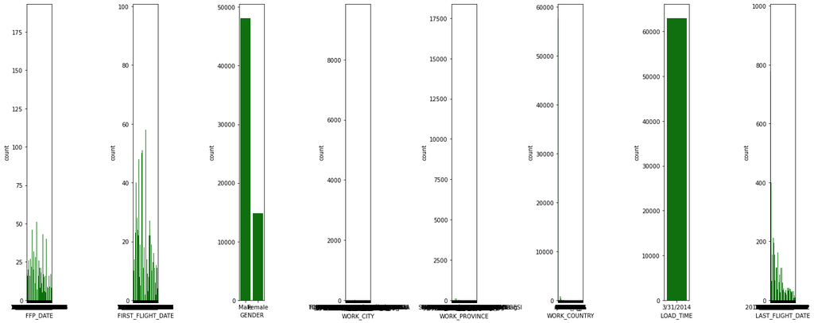

```python
plt.figure(figsize=(20,8))
for i in range(0, len(categorical)):
    plt.subplot(1, len(categorical), i+1)
    sns.countplot(x=df[categorical[i]], color='green', orient='v')
    plt.tight_layout()
```

# Unique value untuk kolom kategorical

```python
for col in df[categorical]:
    print(f'''Value count kolom {col}:''')
    print(df[col].value_counts())
    print()
```

```
Value count kolom FFP_DATE:
1/13/2011     184
1/1/2013      165
3/1/2013      100
11/17/2010     99
1/14/2011      95
             ...
10/4/2005       1
5/18/2009       1
11/29/2004      1
11/7/2004       1
5/19/2009       1
Name: FFP_DATE, Length: 3068, dtype: int64

Value count kolom FIRST_FLIGHT_DATE:
2/16/2013    96
9/30/2012    85
2/15/2013    84
9/9/2005     78
4/21/2012    70
             ..
3/2/2005      1
4/12/2009     1
2/20/2005     1
1/27/2005     1
12/7/2004     1
Name: FIRST_FLIGHT_DATE, Length: 3406, dtype: int64

Value count kolom GENDER:
Male      48134
Female    14851
Name: GENDER, dtype: int64

Value count kolom WORK_CITY:
guangzhou    9386
beijing      7845
shanghai     5001
shenzhen     3605
dalian       1979
             ...
```

[output cut: 37 more lines]

```
Name: LOAD_TIME, dtype: int64

Value count kolom LAST_FLIGHT_DATE:
3/31/2014    959
3/30/2014    933
3/28/2014    924
3/29/2014    779
3/27/2014    767
            ...
4/14/2012      6
4/6/2012       3
4/2/2012       3
4/4/2012       3
4/1/2012       1
Name: LAST_FLIGHT_DATE, Length: 731, dtype: int64
```

# Mencari korelasi yang kuat antara satu sama lain

```python
df.corr()
```

|  | MEMBER_NO | FFP_TIER | AGE | FLIGHT_COUNT | BP_SUM | SUM_YR_1 | SUM_YR_2 | SEG_KM_SUM | LAST_TO_END | AVG_INTERVAL | MAX_INTERVAL | EXCHANGE_COUNT | avg_discount | Points_Sum | Point_NotFlight |
| --- | --- | --- | --- | --- | --- | --- | --- | --- | --- | --- | --- | --- | --- | --- | --- |
| MEMBER_NO | 1.000000 | -0.005910 | 0.001259 | -0.000276 | 0.000063 | -0.002529 | 0.001185 | -0.000032 | -0.002588 | 0.002479 | 0.004761 | -0.003844 | 0.001727 | -0.003613 | -0.033204 |
| FFP_TIER | -0.005910 | 1.000000 | 0.078654 | 0.582447 | 0.581085 | 0.463122 | 0.611385 | 0.522350 | -0.206313 | -0.144928 | -0.127641 | 0.342355 | 0.248845 | 0.559249 | 0.192803 |
| AGE | 0.001259 | 0.078654 | 1.000000 | 0.073246 | 0.100501 | 0.111815 | 0.083743 | 0.087254 | -0.025600 | -0.024613 | 0.009382 | 0.029604 | 0.133235 | 0.074757 | -0.092282 |
| FLIGHT_COUNT | -0.000276 | 0.582447 | 0.073246 | 1.000000 | 0.788379 | 0.748032 | 0.794838 | 0.850411 | -0.404999 | -0.316833 | -0.188682 | 0.502501 | 0.139377 | 0.747092 | 0.291880 |
| BP_SUM | 0.000063 | 0.581085 | 0.100501 | 0.788379 | 1.000000 | 0.850624 | 0.884632 | 0.921724 | -0.319039 | -0.246764 | -0.147953 | 0.530021 | 0.307245 | 0.923271 | 0.244254 |
| SUM_YR_1 | -0.002529 | 0.463122 | 0.111815 | 0.748032 | 0.850624 | 1.000000 | 0.663009 | 0.804125 | -0.186173 | -0.243309 | -0.145206 | 0.488029 | 0.268884 | 0.788354 | 0.235095 |
| SUM_YR_2 | 0.001185 | 0.611385 | 0.083743 | 0.794838 | 0.884632 | 0.663009 | 1.000000 | 0.849195 | -0.423420 | -0.246290 | -0.154905 | 0.468149 | 0.234652 | 0.826666 | 0.237954 |
| SEG_KM_SUM | -0.000032 | 0.522350 | 0.087254 | 0.850411 | 0.921724 | 0.804125 | 0.849195 | 1.000000 | -0.369509 | -0.280746 | -0.155508 | 0.507819 | 0.108393 | 0.853014 | 0.259037 |
| LAST_TO_END | -0.002588 | -0.206313 | -0.025600 | -0.404999 | -0.319039 | -0.186173 | -0.423420 | -0.369509 | 1.000000 | -0.108594 | -0.343939 | -0.169717 | -0.021036 | -0.292027 | -0.124074 |
| AVG_INTERVAL | 0.002479 | -0.144928 | -0.024613 | -0.316833 | -0.246764 | -0.243309 | -0.246290 | -0.280746 | -0.108594 | 1.000000 | 0.724392 | -0.130226 | -0.038814 | -0.220946 | -0.075967 |
| MAX_INTERVAL | 0.004761 | -0.127641 | 0.009382 | -0.188682 | -0.147953 | -0.145206 | -0.154905 | -0.155508 | -0.343939 | 0.724392 | 1.000000 | -0.089417 | -0.016392 | -0.135977 | -0.042843 |
| EXCHANGE_COUNT | -0.003844 | 0.342355 | 0.029604 | 0.502501 | 0.530021 | 0.488029 | 0.468149 | 0.507819 | -0.169717 | -0.130226 | -0.089417 | 1.000000 | 0.112589 | 0.578581 | 0.396115 |
| avg_discount | 0.001727 | 0.248845 | 0.133235 | 0.139377 | 0.307245 | 0.268884 | 0.234652 | 0.108393 | -0.021036 | -0.038814 | -0.016392 | 0.112589 | 1.000000 | 0.263882 | -0.010315 |
| Points_Sum | -0.003613 | 0.559249 | 0.074757 | 0.747092 | 0.923271 | 0.788354 | 0.826666 | 0.853014 | -0.292027 | -0.220946 | -0.135977 | 0.578581 | 0.263882 | 1.000000 | 0.406905 |
| Point_NotFlight | -0.033204 | 0.192803 | -0.092282 | 0.291880 | 0.244254 | 0.235095 | 0.237954 | 0.259037 | -0.124074 | -0.075967 | -0.042843 | 0.396115 | -0.010315 | 0.406905 | 1.000000 |

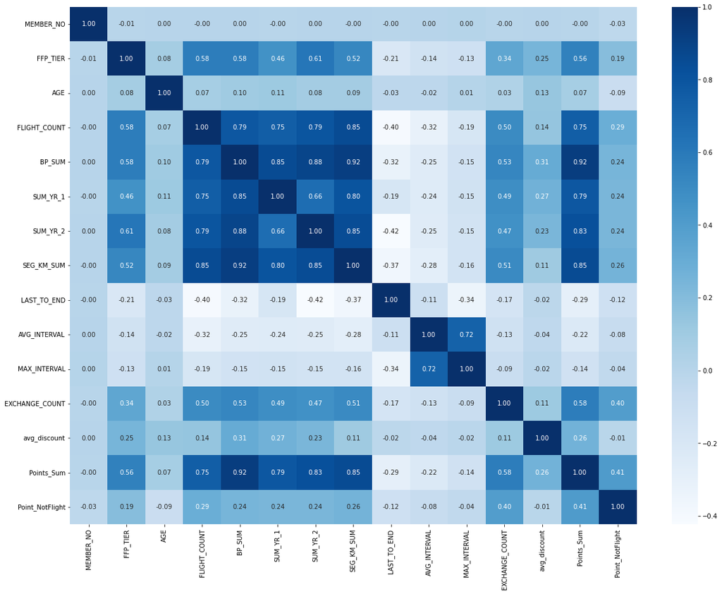

```python
# correlation heatmap
plt.figure(figsize=(20, 15))
sns.heatmap(df.corr(), cmap='Blues', annot=True, fmt='.2f');
```

# Melakukan pengecekan terhadap kolom LAST_FLIGHT_DATE yang memiliki kesalahan dalam penanggalan

```python
df_clean[df_clean.LAST_FLIGHT_DATE.str.contains('2014/2/29')]
```

|  | MEMBER_NO | FFP_DATE | FIRST_FLIGHT_DATE | GENDER | FFP_TIER | WORK_CITY | WORK_PROVINCE | WORK_COUNTRY | AGE | LOAD_TIME | ... | SUM_YR_2 | SEG_KM_SUM | LAST_FLIGHT_DATE | LAST_TO_END | AVG_INTERVAL | MAX_INTERVAL | EXCHANGE_COUNT | avg_discount | Points_Sum | Point_NotFlight |
| --- | --- | --- | --- | --- | --- | --- | --- | --- | --- | --- | --- | --- | --- | --- | --- | --- | --- | --- | --- | --- | --- |
| 248 | 56497 | 6/17/2007 | 6/17/2007 | Female | 6 | guangzhou | guangdong | CN | 46.0 | 3/31/2014 | ... | 70845.0 | 85000 | 2014/2/29 0:00:00 | 32 | 13.250000 | 57 | 0 | 1.373478 | 132653 | 4 |
| 447 | 17306 | 8/26/2009 | 4/29/2010 | Male | 5 | haerbin | heilongjiang | CN | 70.0 | 3/31/2014 | ... | 46323.0 | 69453 | 2014/2/29 0:00:00 | 32 | 22.766667 | 75 | 6 | 1.375395 | 101413 | 7 |
| 473 | 915 | 11/10/2006 | 1/26/2007 | Male | 5 | . | beijing | CN | 39.0 | 3/31/2014 | ... | 30580.0 | 65717 | 2014/2/29 0:00:00 | 32 | 14.250000 | 65 | 1 | 1.425974 | 93153 | 8 |
| 832 | 20336 | 7/13/2005 | 8/6/2005 | Male | 5 | guangzhou | guangdong | CN | 40.0 | 3/31/2014 | ... | 36417.0 | 114222 | 2014/2/29 0:00:00 | 32 | 8.696203 | 34 | 2 | 0.664970 | 91476 | 15 |
| 1051 | 62884 | 5/24/2006 | 4/21/2007 | Male | 5 | wuhan | hubei | CN | 50.0 | 3/31/2014 | ... | 35680.0 | 49859 | 2014/2/29 0:00:00 | 32 | 19.115385 | 72 | 4 | 1.388584 | 69047 | 4 |
| ... | ... | ... | ... | ... | ... | ... | ... | ... | ... | ... | ... | ... | ... | ... | ... | ... | ... | ... | ... | ... | ... |
| 61539 | 55995 | 1/11/2013 | 7/10/2013 | Male | 4 | dalianshi | liaoning | CN | 23.0 | 3/31/2014 | ... | 955.0 | 3513 | 2014/2/29 0:00:00 | 32 | 117.000000 | 211 | 0 | 0.276667 | 0 | 0 |
| 61871 | 48742 | 7/26/2009 | 7/26/2009 | Male | 4 | tianjin | tianjin | CN | 37.0 | 3/31/2014 | ... | 966.0 | 1298 | 2014/2/29 0:00:00 | 32 | 135.000000 | 135 | 0 | 0.690000 | 1094 | 1 |
| 61909 | 9190 | 4/11/2011 | 4/20/2011 | Male | 4 | guangzhou | guangdong | CN | 34.0 | 3/31/2014 | ... | 853.0 | 2595 | 2014/2/29 0:00:00 | 32 | 1.000000 | 1 | 0 | 0.340000 | 3356 | 19 |
| 62721 | 38776 | 10/31/2007 | 3/13/2008 | Male | 4 | foshan | guangdong | CN | 42.0 | 3/31/2014 | ... | 688.0 | 1199 | 2014/2/29 0:00:00 | 32 | 78.000000 | 78 | 0 | 0.489525 | 276 | 0 |
| 62929 | 46449 | 2/7/2010 | 7/31/2010 | Male | 4 | guangzhoushi | guangdong | CN | 24.0 | 3/31/2014 | ... | 401.0 | 1312 | 2014/2/29 0:00:00 | 32 | 43.000000 | 43 | 0 | 0.275000 | 1211 | 3 |

419 rows × 23 columns

```python
print('Incorrect `LAST_FLIGHT_DATE data percentage:', end='\n\n')
print(str(round(df_clean[df_clean.LAST_FLIGHT_DATE.str.contains('2014/2/29')]['LAST_FLIGHT_DATE'].count()/len(df_clean),3)),'%')
```

```
Incorrect `LAST_FLIGHT_DATE data percentage:

0.007 %
```

```python
df_clean.drop(df_clean[df_clean.LAST_FLIGHT_DATE.str.contains('2014/2/29')].index, inplace=True)
```

Mengecek Apakah kolom tersebut sudah di drop

```python
df_clean[df_clean.LAST_FLIGHT_DATE.str.contains('2014/2/29')]['LAST_FLIGHT_DATE'].count()
```

```
0
```

Mengubah tipe data AGE menjadi integer

```python
df_clean['AGE'] = df_clean['AGE'].astype(int)
```

Mengubah tipe data pada kolom `FFP_DATE`, `FIRST_FLIGHT_DATE`, `LOAD_TIME`, `LAST_FLIGHT_DATE` menjadi tipe data datetime

```python
date_col = ['FFP_DATE', 'FIRST_FLIGHT_DATE', 'LOAD_TIME', 'LAST_FLIGHT_DATE']
for col in date_col:
    df_clean[col] = pd.to_datetime(df_clean[col])
```

```python
df_clean.info()
```

```
<class 'pandas.core.frame.DataFrame'>
Int64Index: 61437 entries, 0 to 62986
Data columns (total 23 columns):
 #   Column             Non-Null Count  Dtype
---  ------             --------------  -----
 0   MEMBER_NO          61437 non-null  int64
 1   FFP_DATE           61437 non-null  datetime64[ns]
 2   FIRST_FLIGHT_DATE  61437 non-null  datetime64[ns]
 3   GENDER             61437 non-null  object
 4   FFP_TIER           61437 non-null  int64
 5   WORK_CITY          61437 non-null  object
 6   WORK_PROVINCE      61437 non-null  object
 7   WORK_COUNTRY       61437 non-null  object
 8   AGE                61437 non-null  int32
 9   LOAD_TIME          61437 non-null  datetime64[ns]
 10  FLIGHT_COUNT       61437 non-null  int64
 11  BP_SUM             61437 non-null  int64
 12  SUM_YR_1           61437 non-null  float64
 13  SUM_YR_2           61437 non-null  float64
 14  SEG_KM_SUM         61437 non-null  int64
 15  LAST_FLIGHT_DATE   61437 non-null  datetime64[ns]
 16  LAST_TO_END        61437 non-null  int64
 17  AVG_INTERVAL       61437 non-null  float64
 18  MAX_INTERVAL       61437 non-null  int64
 19  EXCHANGE_COUNT     61437 non-null  int64
 20  avg_discount       61437 non-null  float64
 21  Points_Sum         61437 non-null  int64
 22  Point_NotFlight    61437 non-null  int64
dtypes: datetime64[ns](4), float64(4), int32(1), int64(10), object(4)
memory usage: 11.0+ MB
```

# Kesimpulan

- Tipe data yang dihasilkan dari semua data sudah memiliki tipe data yang sesuai

# Feature Engineering

1. Pilih fitur-fitur yang menurut teman-teman masuk akal secara bisnis untuk digunakan sebagai fitur clustering. Lakukan Feature engineering!  
   Langkah-langkah:
- Dari sekian banyak kolom yang ada, tentukan 3-6 fitur untuk digunakan sebagai fitur `clustering`. Tulis alasan teman-teman memilih fitur tersebut.
- Lakukan preprocessing dan feature engineering (apabila fitur teman-teman merupakan fitur baru yang dihasilkan dari fitur-fitur yang sudah ada)

Fitur yang akan dipilih oleh kelompok kami

- FLIGHT_COUNT
- MEMBER_DURATION
- SEG_KM_SUM
- avg_discount
- LAST_TO_END  
  alasan : Karena pada feature tersebut kita mau membaca data berapa lama customer memiliki membership pesawat dan berapa discount yang diberikan oleh pihak maskapai untuk customer tersebut

# Preprocessing

Dari EDA kita dapat melihat kolom age memiliki nilai outlier yang tidak wajar dikarenakan ada pelanggan yang berumur 110 tahun

```python
df_clean[df_clean.AGE > 100]
```

[output not shown]

1 rows × 24 columns

```python
df_clean.drop(df_clean[df_clean.AGE > 100].index, inplace=True)
```

Dari data yang sudah ada terdapat anomali data sehingga kita harus membuat data yang mempunyai harga tiket 0, total diskon yang diberikan 0, dan jarak yang ditempuh lebih dari 0 sehingga data tesebut harus di drop

```python
df_clean[(df_clean.SUM_YR_1 == 0) & (df_clean.SUM_YR_2 == 0) &
         (df_clean.avg_discount == 0) & (df_clean.SEG_KM_SUM > 0)]
```

[output not shown]

7 rows × 24 columns

```python
df_clean.drop(df_clean[(df_clean.SUM_YR_1 == 0) & (df_clean.SUM_YR_2 == 0)
                      & (df_clean.avg_discount == 0)
                      & (df_clean.SEG_KM_SUM > 0)].index, inplace=True)
```

```python
print('Total Row', df_clean.shape[0], ', Total Feature', df_clean.shape[1],
      '\n')
```

[output not shown]

## Menghitung membership duration (dalam bulan)

Dengan mengurangi kolom `LOAD_TIME` dan kolom `FPP_DATE`, kita dapat tahu berapa lama pelanggan membuat membership, dan kita bisa mengetahui yang mana customer baru / lama

```python
df_clean['MEMBER_DURATION'] = ((df_clean['LOAD_TIME'] - df_clean['FFP_DATE'])/np.timedelta64(1, 'M'))
df_clean['MEMBER_DURATION'] = df_clean['MEMBER_DURATION'].astype(int)
```

```python
df_clean.sample(2)
```

|  | MEMBER_NO | FFP_DATE | FIRST_FLIGHT_DATE | GENDER | FFP_TIER | WORK_CITY | WORK_PROVINCE | WORK_COUNTRY | AGE | LOAD_TIME | ... | SEG_KM_SUM | LAST_FLIGHT_DATE | LAST_TO_END | AVG_INTERVAL | MAX_INTERVAL | EXCHANGE_COUNT | avg_discount | Points_Sum | Point_NotFlight | MEMBER_DURATION |
| --- | --- | --- | --- | --- | --- | --- | --- | --- | --- | --- | --- | --- | --- | --- | --- | --- | --- | --- | --- | --- | --- |
| 51457 | 2783 | 2007-10-07 | 2007-10-07 | Female | 4 | dalian | liaoning | CN | 24 | 2014-03-31 | ... | 3019 | 2013-05-04 | 333 | 81.000000 | 81 | 0 | 0.838357 | 2366 | 0 | 77 |
| 14560 | 26349 | 2012-09-03 | 2012-09-03 | Male | 5 | zhongshan | dalian | CN | 50 | 2014-03-31 | ... | 20144 | 2014-03-25 | 7 | 21.884615 | 91 | 0 | 0.810717 | 15096 | 0 | 18 |

2 rows × 24 columns

# 3. Clustering K-means

Lakukan clustering K-means! Temukan jumlah cluster yang menurut teman-teman optimal dan evaluasi cluster yang dihasilkan dengan visualisasi dan silhouette score  
langkah-langkah:

- Temukan jumlah cluster yang optimal dengan menggunakan elbow method
- Lakukan clustering menggunakan K-means
- Evaluasi cluster yang dihasilkan dengan menggunakan visualisasi, gunakan PCA apabila diperlukan

```python
df_select = df_clean.copy()
```

```python
df_select = df_select[['MEMBER_DURATION', 'LAST_TO_END', 'FLIGHT_COUNT',
                       'SEG_KM_SUM', 'avg_discount']]
df_select.sample(5)
```

|  | MEMBER_DURATION | LAST_TO_END | FLIGHT_COUNT | SEG_KM_SUM | avg_discount |
| --- | --- | --- | --- | --- | --- |
| 25231 | 26 | 201 | 9 | 12715 | 0.740720 |
| 5226 | 19 | 8 | 36 | 48909 | 0.678766 |
| 34114 | 91 | 447 | 5 | 8957 | 0.688462 |
| 14298 | 12 | 140 | 9 | 25129 | 0.660056 |
| 32171 | 13 | 225 | 3 | 7406 | 0.911739 |

```python
# Before scaling
df_select.describe()
```

|  | MEMBER_DURATION | LAST_TO_END | FLIGHT_COUNT | SEG_KM_SUM | avg_discount |
| --- | --- | --- | --- | --- | --- |
| count | 61429.000000 | 61429.000000 | 61429.000000 | 61429.000000 | 61429.000000 |
| mean | 48.215761 | 173.550245 | 11.940956 | 17277.610917 | 0.721726 |
| std | 27.818950 | 181.473954 | 14.119509 | 21055.460423 | 0.184697 |
| min | 11.000000 | 1.000000 | 2.000000 | 368.000000 | 0.112043 |
| 25% | 24.000000 | 28.000000 | 3.000000 | 4850.000000 | 0.612569 |
| 50% | 41.000000 | 107.000000 | 7.000000 | 10150.000000 | 0.711807 |
| 75% | 71.000000 | 262.000000 | 15.000000 | 21433.000000 | 0.808997 |
| max | 112.000000 | 731.000000 | 213.000000 | 580717.000000 | 1.500000 |

```python
# Normalization
from sklearn.preprocessing import StandardScaler, MinMaxScaler

norm_col = ['MEMBER_DURATION', 'LAST_TO_END', 'FLIGHT_COUNT', 'SEG_KM_SUM']

for col in norm_col:
    df_select[col + '_NORM'] = MinMaxScaler().fit_transform(df_select[col].values.reshape(len(df_select), 1))

# Standarisation
df_select['avg_discount_STD'] = StandardScaler().fit_transform(df_select['avg_discount'].values.reshape(len(df_select), 1))
```

```python
# After Scaling
df_select.describe()
```

|  | MEMBER_DURATION | LAST_TO_END | FLIGHT_COUNT | SEG_KM_SUM | avg_discount | MEMBER_DURATION_NORM | LAST_TO_END_NORM | FLIGHT_COUNT_NORM | SEG_KM_SUM_NORM | avg_discount_STD |
| --- | --- | --- | --- | --- | --- | --- | --- | --- | --- | --- |
| count | 61429.000000 | 61429.000000 | 61429.000000 | 61429.000000 | 61429.000000 | 61429.000000 | 61429.000000 | 61429.000000 | 61429.000000 | 6.142900e+04 |
| mean | 48.215761 | 173.550245 | 11.940956 | 17277.610917 | 0.721726 | 0.368473 | 0.236370 | 0.047114 | 0.029137 | 1.890226e-15 |
| std | 27.818950 | 181.473954 | 14.119509 | 21055.460423 | 0.184697 | 0.275435 | 0.248594 | 0.066917 | 0.036281 | 1.000008e+00 |
| min | 11.000000 | 1.000000 | 2.000000 | 368.000000 | 0.112043 | 0.000000 | 0.000000 | 0.000000 | 0.000000 | -3.301023e+00 |
| 25% | 24.000000 | 28.000000 | 3.000000 | 4850.000000 | 0.612569 | 0.128713 | 0.036986 | 0.004739 | 0.007723 | -5.910148e-01 |
| 50% | 41.000000 | 107.000000 | 7.000000 | 10150.000000 | 0.711807 | 0.297030 | 0.145205 | 0.023697 | 0.016855 | -5.370799e-02 |
| 75% | 71.000000 | 262.000000 | 15.000000 | 21433.000000 | 0.808997 | 0.594059 | 0.357534 | 0.061611 | 0.036297 | 4.725116e-01 |
| max | 112.000000 | 731.000000 | 213.000000 | 580717.000000 | 1.500000 | 1.000000 | 1.000000 | 1.000000 | 1.000000 | 4.213829e+00 |

```python
# Filtering kolom std
df_select_std = df_select.copy()
df_select_std = df_select_std[['MEMBER_DURATION_NORM', 'LAST_TO_END_NORM',
                               'FLIGHT_COUNT_NORM', 'SEG_KM_SUM_NORM',
                               'avg_discount_STD']]
```

```python
df_select_std.sample(5)
```

|  | MEMBER_DURATION_NORM | LAST_TO_END_NORM | FLIGHT_COUNT_NORM | SEG_KM_SUM_NORM | avg_discount_STD |
| --- | --- | --- | --- | --- | --- |
| 59164 | 0.237624 | 0.961644 | 0.000000 | 0.001971 | 1.091997 |
| 49 | 0.326733 | 0.415068 | 0.322275 | 0.377211 | 0.767498 |
| 60587 | 0.693069 | 0.190411 | 0.004739 | 0.009406 | -2.832834 |
| 41273 | 0.584158 | 0.821918 | 0.004739 | 0.010397 | -0.207872 |
| 43176 | 0.138614 | 0.001370 | 0.009479 | 0.008248 | 0.254312 |

# Clustering (K-Means)

Menemukan kluster yang ideal dan menghitung shilhouette score

## Inertia

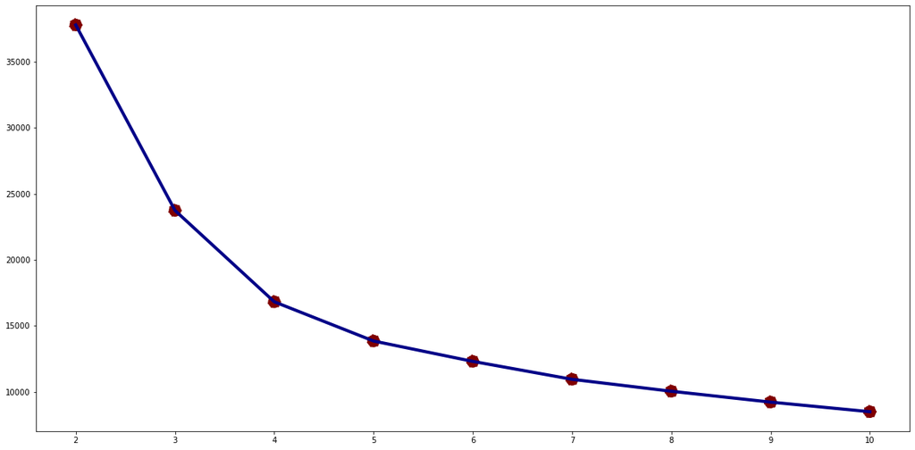

```python
from sklearn.cluster import KMeans
inertia = []

for i in range(2, 11):
    kmeans = KMeans(n_clusters=i, random_state=0)
    kmeans.fit(df_select_std)
    inertia.append(kmeans.inertia_)



plt.figure(figsize=(20, 10))

sns.lineplot(x=range(2, 11), y=inertia, color='#000087', linewidth = 4)
sns.scatterplot(x=range(2, 11), y=inertia, s=300, color='#800000',  linestyle='--')
plt.show()
```

## Silhouette Score

```python
from sklearn.metrics import silhouette_score

range_n_clusters = list(range(2,11))
arr_silhouette_score_euclidean = []
for i in range_n_clusters:
    kmeans = KMeans(n_clusters=i).fit(df_select_std)
    preds = kmeans.predict(df_select_std)

    score_euclidean = silhouette_score(df_select_std, preds, metric='euclidean')
    arr_silhouette_score_euclidean.append(score_euclidean)
```

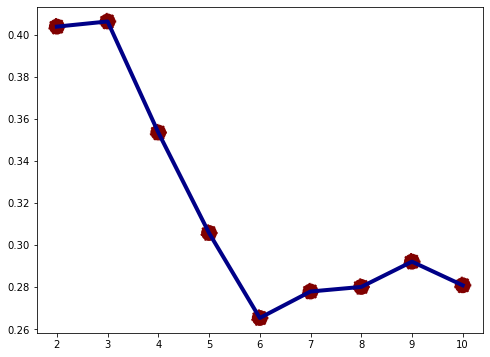

```python
fig, ax = plt.subplots(figsize=(8, 6))
sns.lineplot(x=range(2,11), y=arr_silhouette_score_euclidean, color='#000087', linewidth = 4)
sns.scatterplot(x=range(2,11), y=arr_silhouette_score_euclidean, s=300, color='#800000',  linestyle='--')
plt.show()
```

Dilihat dari nilai inertia atau silhouette score, informasi yang didapat bahwa nilai cluster yang ideal adalah 3

```python
# Membuat KMeans dengan 3 cluster
kmeans = KMeans(n_clusters=3, random_state=42).fit(df_select_std)
```

```python
# Menerapkan cluster pada dataset
clusters = kmeans.labels_
```

```python
df_clean['clusters'] = clusters
```

# Clusters Analysis

## Dimensionality Reduction for Visualization

```python
from sklearn.decomposition import PCA

pca = PCA(n_components=2)

pca.fit(df_select_std)
pcs = pca.transform(df_select_std)

df_pca = pd.DataFrame(data = pcs, columns = ['PC 1', 'PC 2'])
df_pca.head()
```

|  | PC 1 | PC 2 |
| --- | --- | --- |
| 0 | 1.322036 | 0.536434 |
| 1 | 2.889383 | 0.421894 |
| 2 | 2.901836 | 0.416626 |
| 3 | 2.005285 | 0.185232 |
| 4 | 1.359489 | 0.235990 |

```python
df_pca['clusters'] = clusters
df_pca.head(2)
```

|  | PC 1 | PC 2 | clusters |
| --- | --- | --- | --- |
| 0 | 1.322036 | 0.536434 | 0 |
| 1 | 2.889383 | 0.421894 | 2 |

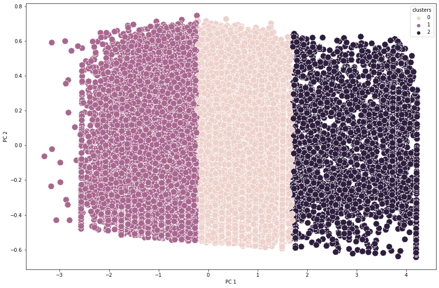

```python
fig, ax = plt.subplots(figsize=(15,10))

sns.scatterplot(
    x='PC 1', y='PC 2',
    hue='clusters',
    linestyle='--',
    data=df_pca,
    s=160,
    ax=ax
)

plt.show()
```

# Analisis

```python
df_clean[['MEMBER_DURATION', 'LAST_TO_END', 'FLIGHT_COUNT', 'SEG_KM_SUM', 'avg_discount', 'clusters']].groupby('clusters').median()
```

| clusters | MEMBER_DURATION | LAST_TO_END | FLIGHT_COUNT | SEG_KM_SUM | avg_discount |
| --- | --- | --- | --- | --- | --- |
| 0 | 43.0 | 102.0 | 8.0 | 10846.0 | 0.782476 |
| 1 | 39.0 | 114.0 | 6.0 | 9176.0 | 0.591321 |
| 2 | 53.0 | 78.0 | 9.0 | 12898.0 | 1.275279 |

```python
df_clean['clusters'].value_counts().to_frame().reset_index().rename(columns={"index": "clusters", "clusters": "total_members"})
```

|  | clusters | total_members |
| --- | --- | --- |
| 0 | 0 | 33067 |
| 1 | 1 | 25792 |
| 2 | 2 | 2570 |

# 4. Interpretasi cluster yang dihasilkan secara bisnis dan berikan rekomendasi yang sesuai dengan cluster yang dihasilkan

- Tempelkan kembali label yang dihasilkan ke dataframe asal, dan keluarkan statistik fitur dari setiap cluster
- Deskripsikan secara kontekstual customer seperti apa yang ada di masing2 cluster
- Berdasarkan cluster tersebut, berikan 1-2 rekomendasi strategi bisnis untuk stakeholder!

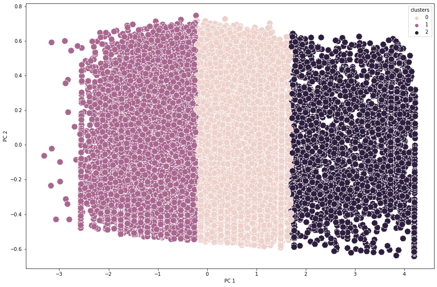

```python
fig, ax = plt.subplots(figsize=(15,10))

sns.scatterplot(
    x='PC 1', y='PC 2',
    hue='clusters',
    linestyle='--',
    data=df_pca,
    s=160,
    ax=ax
)

plt.show()
```

```python
df_clean[['MEMBER_DURATION', 'LAST_TO_END', 'FLIGHT_COUNT', 'SEG_KM_SUM', 'avg_discount', 'clusters']].groupby('clusters').median()
```

| clusters | MEMBER_DURATION | LAST_TO_END | FLIGHT_COUNT | SEG_KM_SUM | avg_discount |
| --- | --- | --- | --- | --- | --- |
| 0 | 43.0 | 102.0 | 8.0 | 10846.0 | 0.782476 |
| 1 | 39.0 | 114.0 | 6.0 | 9176.0 | 0.591321 |
| 2 | 53.0 | 78.0 | 9.0 | 12898.0 | 1.275279 |

```python
df_clean['clusters'].value_counts().to_frame().reset_index().rename(columns={"index": "clusters", "clusters": "total_members"})
```

|  | clusters | total_members |
| --- | --- | --- |
| 0 | 0 | 33067 |
| 1 | 1 | 25792 |
| 2 | 2 | 2570 |

Cluster 0 (middle class customer):

Cluster 1 (Low Class Customer):

Cluster 2 (High Class Customer):

# Business Recomendation

- Mempertahankan high class customer dengan memberikan fasilitas first class dan airpot lounge agar dapat meningkatkan kepuasan konsumen
- Memberikan promo yang menarik pada middle class dan low class customer agar dapat meningkatkan transaksi pembelian tiket pesawat dan memberi reedem point yang bertujuan untuk penukaran tiket pesawat gratis